# Математика — Домашнее задание 12

**Дедлайн:** 23:59, 21 февраля

## Задание

Выполнить задания из файла по ссылке.

Для выполнения домашнего задания можно использовать скрипт с заранее подготовленными функциями,  
который был продемонстрирован на лекции. Скрипт также прикреплён к материалам занятия.  
Также можно дописать свои кастомные функции, если текущего функционала скрипта не хватает.

### Критерии зачёта:

- **Зачёт на 4:** от 7 баллов
- **Зачёт на 5:** от 9 баллов

# №5 (3 балла)

Сгенерируйте датасет со случайными нормально распределёнными величинами  
$x_1 \sim N(\mu_1, \sigma_1^2), x_2 \sim N(\mu_2, \sigma_2^2), \text{corr}(x_1, x_2) = -0.7$, размер выборки $N = 1000$

Сгенерируйте зависимую переменную $y$ по формуле:
$$ y = \beta_0 + \beta_1 x_1 + \beta_2 x_2 + \varepsilon $$
где $\varepsilon \sim N(0, \sigma_{\varepsilon}^2), \beta_i \neq 0$.

## Задача

1. **(1 балл)** Оцените модель методом МНК, выведите репорт с результатами модели, дайте трактовку полученным оценкам коэффициентов модели $\hat{\beta}_1$ и $\hat{\beta}_2$, проведите тесты на нормальность распределения остатков и дайте свои комментарии.
2. **(3 балла)** Отрисуйте графики:
   - $y$ vs $x_1$, $y$ vs $x_2$, $y$ vs $\hat{y}$, распределения остатков модели. Дайте свои комментарии.
   - Проведите симуляцию изменения результатов модели в зависимости от размера выборки $N$ (через цикл или параллельные вычисления) для $N = 30 \dots 1000$, сохраняя оценки и стандартные ошибки коэффициентов $\hat{\beta}_1$ и $\hat{\beta}_2$.
   - Отрисуйте графики зависимости оценок коэффициентов $\hat{\beta}_1$ и $\hat{\beta}_2$ от $N$. Добавьте на этих графиках верхнюю и нижнюю границу двустороннего доверительного интервала оценок $\hat{\beta}_1$ и $\hat{\beta}_2$ при $\alpha = 5\%$. Дайте комментарии по результатам, которые видите на графике.

```python
# Подключим нужные для базовых операций библиотеки
import seaborn as sb
from matplotlib import pyplot as plt
import numpy as np
import pandas as pd

# Подключим пакеты для использования OLS метода и тестов
import statsmodels.api as sm
from sklearn.linear_model import LinearRegression
from scipy import stats
from statsmodels.stats.outliers_influence import variance_inflation_factor

# Подгрузим полезные функции
from utils import *

# Сделаем автоподгрузку всех изменений при перепрогонке ячейки
%load_ext autoreload
%autoreload 2
```

## Генерация датасета

```python
# Определим параметры выборки для задачи преобразования факторов
# Создадим удобный словарь, чтобы передавать его в функцию
dist_params = dict(

    # Зададим параметры распределения факторов
    x1_mean = 100.0,
    x1_std = 20.0,
    x2_mean = 30.0,
    x2_std = 6.0,
    corr_12 = -0.7,

    # Зададим параметры распределения ошибки
    e_mean = 0,
    e_std = 100.0,

    # Укажем размер выборки
    N = 1000, # 1к

    # Зададим действительные параметры модели
    beta0 = 50,
    beta1 = 6.7,
    beta2 = 2.3
)

# Установим стартовую точку для алгоритма генерации случайных чисел
RANDOM_SEED = 42
```

```python
# Сгенерируем датасет с нормальным распределением в регрессоре

dt_multivariate = gen_data(y_type='multivariate', params=dist_params, seed=RANDOM_SEED)
display(dt_multivariate)
```

|  | x1 | x2 | e | y |
| --- | --- | --- | --- | --- |
| 0 | 89.951492 | 31.613981 | -67.517827 | 657.869326 |
| 1 | 88.428076 | 39.074185 | -14.451867 | 717.886868 |
| 2 | 104.467916 | 28.014423 | -79.241992 | 735.126218 |
| 3 | 69.137349 | 40.070248 | -30.796153 | 574.585653 |
| 4 | 109.867607 | 30.159853 | -189.361467 | 666.119164 |
| ... | ... | ... | ... | ... |
| 995 | 84.685869 | 36.598846 | 7.748052 | 709.320718 |
| 996 | 76.882311 | 38.115546 | 25.775254 | 678.552493 |
| 997 | 93.939891 | 35.921101 | -124.176058 | 637.839741 |
| 998 | 99.737340 | 26.275162 | 33.417642 | 812.090692 |
| 999 | 102.588594 | 26.236421 | -15.525905 | 782.161440 |

1000 rows × 4 columns

### 1. **(1 балл)** Оцените модель методом МНК, выведите репорт с результатами модели, дайте трактовку полученным оценкам коэффициентов модели $\hat{\beta}_1$ и $\hat{\beta}_2$, проведите тесты на нормальность распределения остатков и дайте свои комментарии.

```
                            OLS Regression Results
==============================================================================
Dep. Variable:                      y   R-squared:                       0.589
Model:                            OLS   Adj. R-squared:                  0.588
Method:                 Least Squares   F-statistic:                     713.5
Date:                Sat, 22 Feb 2025   Prob (F-statistic):          4.49e-193
Time:                        17:51:53   Log-Likelihood:                -6006.4
No. Observations:                1000   AIC:                         1.202e+04
Df Residuals:                     997   BIC:                         1.203e+04
Df Model:                           2
Covariance Type:            nonrobust
==============================================================================
                 coef    std err          t      P>|t|      [0.025      0.975]
------------------------------------------------------------------------------
const         41.9995     40.145      1.046      0.296     -36.778     120.777
x1             6.6552      0.221     30.162      0.000       6.222       7.088
x2             2.7290      0.716      3.812      0.000       1.324       4.134
==============================================================================
Omnibus:                        1.796   Durbin-Watson:                   2.024
Prob(Omnibus):                  0.407   Jarque-Bera (JB):                1.687
Skew:                           0.059   Prob(JB):                        0.430
Kurtosis:                       3.163   Cond. No.                     1.36e+03
==============================================================================

Notes:
[1] Standard Errors assume that the covariance matrix of the errors is correctly specified.
[2] The condition number is large, 1.36e+03. This might indicate that there are
strong multicollinearity or other numerical problems.
```

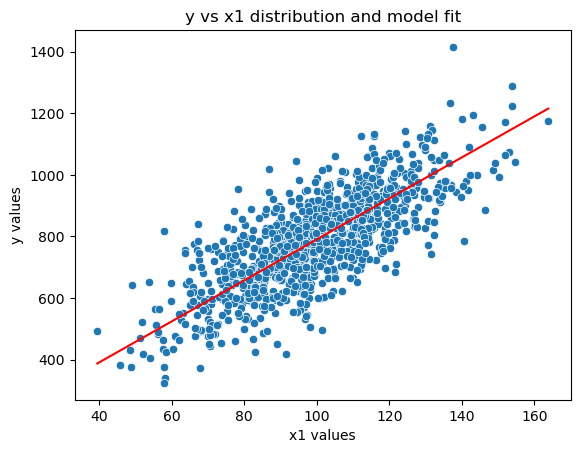

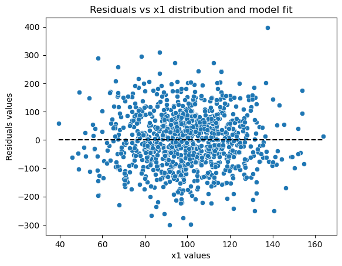

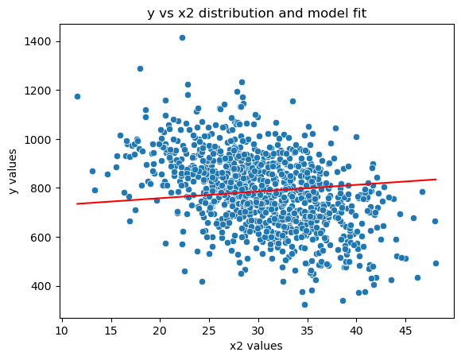

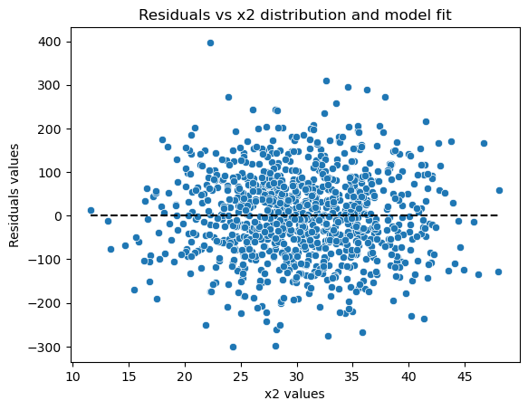

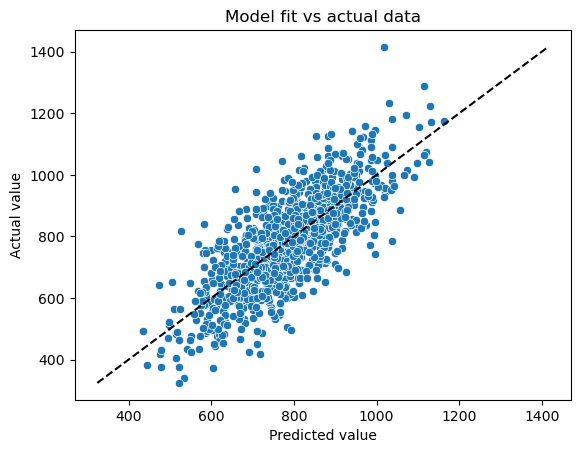

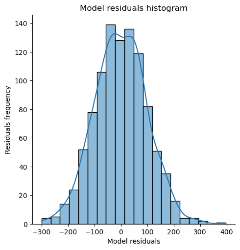

|  | test | p_level | a_level | a_calc | a_calc >= a_level | statistic | critical_value | statistic < critical_value | conclusion |
| --- | --- | --- | --- | --- | --- | --- | --- | --- | --- |
| 0 | Shapiro-Wilk test | 0.95 | 0.05 | 0.671426 | True | 0.998675 |  |  | gaussian distribution |
| 1 | Epps-Pulley test | 0.95 | 0.05 | 0.957763 | True | 0.014878 | 0.3778 | True | gaussian distribution |
| 2 | D'Agostino's K-squared test | 0.95 | 0.05 | 0.407309 | True | 1.796368 |  |  | gaussian distribution |
| 3 | Anderson-Darling test | 0.95 | 0.05 |  |  | 0.225355 | 0.784 | True | gaussian distribution |
| 4 | Kolmogorov–Smirnov test | 0.95 | 0.05 | 0.884376 | True | 0.018314 |  |  | gaussian distribution |
| 5 | Lilliefors test | 0.95 | 0.05 | 0.641481 | True | 0.018434 |  |  | gaussian distribution |
| 6 | Cramér–von Mises test | 0.95 | 0.05 | 0.956451 | True | 0.035144 |  |  | gaussian distribution |
| 7 | Chi-squared test | 0.95 | 0.05 | 0.0 | False | 51177268492846530560.0 |  |  | not gaussian distribution |
| 8 | Jarque–Bera test | 0.95 | 0.05 | - | - | - |  |  | count less than 2000 |
| 9 | skewtest | 0.95 | 0.05 | 0.445155 | True | 0.763517 |  |  | gaussian distribution |
| 10 | kurtosistest | 0.95 | 0.05 | 0.270658 | True | 1.101549 |  |  | gaussian distribution |

```python
# Обучим модель и выведем результаты

dt_multivariate, model_dt_multivariate = train_model(dt_multivariate, target='y', feature_names=['x1', 'x2'], show_results=True, return_norm_tests=True)
```

#### Выводы:

```
'''
# Зададим действительные параметры модели
beta0 = 50,
beta1 = 6.7,
beta2 = 2.3

# Зададим параметры распределения факторов
x1_mean = 100.0,
x1_std = 20.0,
x2_mean = 30.0,
x2_std = 6.0,
corr_12 = -0.7,
'''
```

### Результаты оценки модели:

[output not shown]

Можно заметить, что модель достаточно неплохо приближает реальные значения коэффициентов $\beta_i$.  
Полученные оценки коэффициентов близки к реальным: регрессоры $x_1$ и $x_2$ получились крайне близкими к истинным значениям. Доверительный интервал для $x_1$ достаточно узкий, чего, однако, нельзя сказать про доверительный интервал оценки регрессора $x_2$.

Говоря про свободный коэффициент $\beta_0$, он получился достаточно близким к истинному значению, но с крайне широким доверительным интервалом (из-за особенностей сгенерированных данных).
Сама по себе модель не очень хорошо приближает данные:
$$ R^2 = 0.589 $$
$$ \text{Скорректированный } R^2 = 0.588 $$

Показатель неплох для реальных данных, но для симуляции, на мой взгляд, значение достаточно низкое, хоть мы и добавляем при генерации искусственный шум и фактор скоррелированности регрессоров.

В целом можно сказать, что относительно высокий показатель мультиколлинеарности оказал негативное воздействие на качество работы алгоритма. Здесь можно применить несколько эвристик, чтобы снизить число обусловленности решения. Самая простая, на мой взгляд, — увеличить количество данных в выборке.

Насчет нормальности распределения остатков - большинство тестов говорит, что остатки у нас распределены нормально.

### 2. **(3 балла)** Отрисуйте графики:

- $y$ vs $x_1$, $y$ vs $x_2$, $y$ vs $\hat{y}$, распределения остатков модели. Дайте свои комментарии.

```
                            OLS Regression Results
==============================================================================
Dep. Variable:                      y   R-squared:                       0.589
Model:                            OLS   Adj. R-squared:                  0.588
Method:                 Least Squares   F-statistic:                     713.5
Date:                Sat, 22 Feb 2025   Prob (F-statistic):          4.49e-193
Time:                        17:51:57   Log-Likelihood:                -6006.4
No. Observations:                1000   AIC:                         1.202e+04
Df Residuals:                     997   BIC:                         1.203e+04
Df Model:                           2
Covariance Type:            nonrobust
==============================================================================
                 coef    std err          t      P>|t|      [0.025      0.975]
------------------------------------------------------------------------------
const         41.9995     40.145      1.046      0.296     -36.778     120.777
x1             6.6552      0.221     30.162      0.000       6.222       7.088
x2             2.7290      0.716      3.812      0.000       1.324       4.134
==============================================================================
Omnibus:                        1.796   Durbin-Watson:                   2.024
Prob(Omnibus):                  0.407   Jarque-Bera (JB):                1.687
Skew:                           0.059   Prob(JB):                        0.430
Kurtosis:                       3.163   Cond. No.                     1.36e+03
==============================================================================

Notes:
[1] Standard Errors assume that the covariance matrix of the errors is correctly specified.
[2] The condition number is large, 1.36e+03. This might indicate that there are
strong multicollinearity or other numerical problems.
```

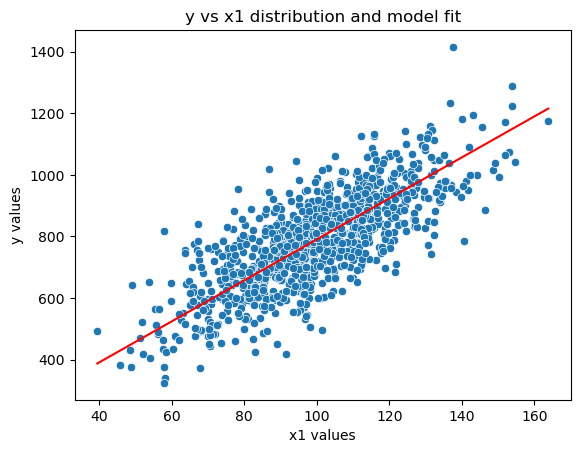

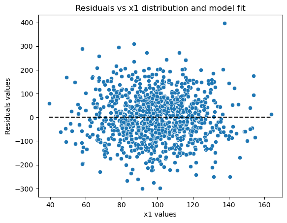

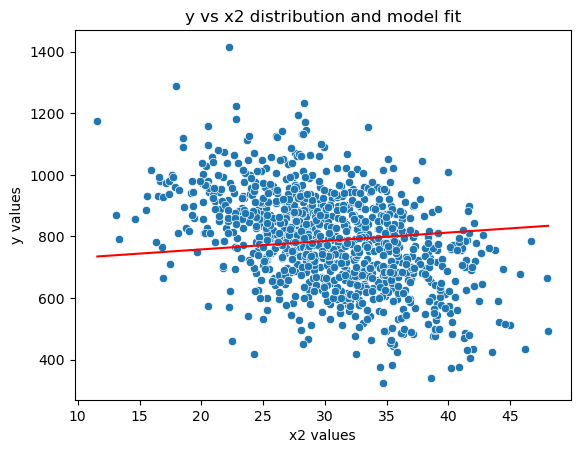

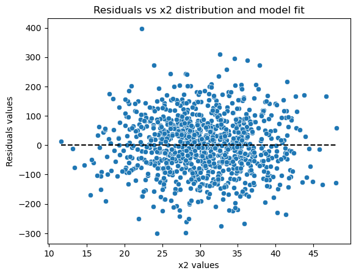

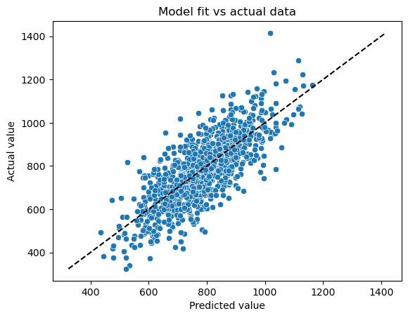

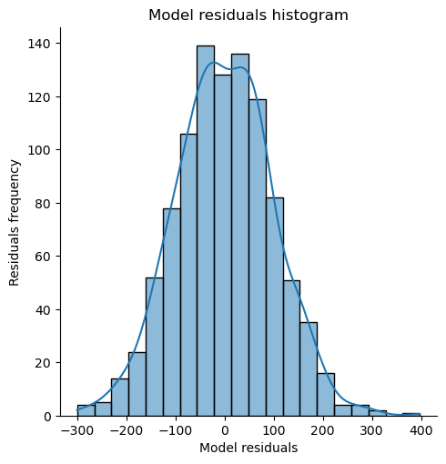

```python
dt_multivariate, model_dt_multivariate = train_model(dt_multivariate, target='y', feature_names=['x1', 'x2'], show_results=True, pairwise=False, return_norm_tests=False)
```

### Выводы:

Значимых проблем не вижу. Зависимость действительно линейная. Тем не менее, фактор корреляции, наличие выбросов и базово подобранные значения привносят свой вклад в модель.

### 2. **(3 балла)** Отрисуйте графики:

- Проведите симуляцию изменения результатов модели в зависимости от размера выборки $N$ (через цикл или параллельные вычисления) для $N = 30 \dots 1000$, сохраняя оценки и стандартные ошибки коэффициентов $\hat{\beta}_1$ и $\hat{\beta}_2$.
- Отрисуйте графики зависимости оценок коэффициентов $\hat{\beta}_1$ и $\hat{\beta}_2$ от $N$. Добавьте на этих графиках верхнюю и нижнюю границу двустороннего доверительного интервала оценок $\hat{\beta}_1$ и $\hat{\beta}_2$ при $\alpha = 5\%$. Дайте комментарии по результатам, которые видите на графике.

```python
# Создаем словарь для хранения коэффициентов и доверительных интервалов
coefficients = {
    'beta1': [], 'beta1_low': [], 'beta1_high': [],
    'beta2': [], 'beta2_low': [], 'beta2_high': []
}

# Перебираем размер выборки от 30 до 1000
for sample_size in range(30, 1001):
    dist_params['N'] = sample_size

    # Генерируем данные и обучаем модель
    data = gen_data(y_type='multivariate', params=dist_params, seed=RANDOM_SEED)
    _, model = train_model(data, target='y', feature_names=['x1', 'x2'])

    # Получаем доверительные интервалы
    conf_intervals = model.conf_int()

    # Сохраняем коэффициенты и границы доверительных интервалов
    coefficients['beta1'].append(model.params.iloc[1])
    coefficients['beta1_low'].append(conf_intervals.iloc[1, 0])
    coefficients['beta1_high'].append(conf_intervals.iloc[1, 1])
    coefficients['beta2'].append(model.params.iloc[2])
    coefficients['beta2_low'].append(conf_intervals.iloc[2, 0])
    coefficients['beta2_high'].append(conf_intervals.iloc[2, 1])
```

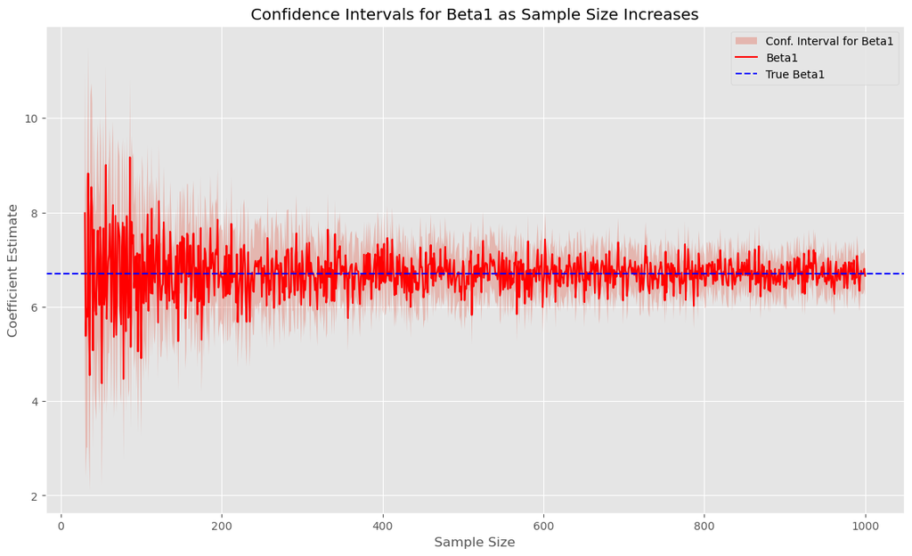

[figure not shown]

```python
# Визуализация
plt.style.use('ggplot')
plt.figure(figsize=(14, 8))

X = list(range(30, 1001))
plt.fill_between(X, coefficients['beta1_low'], coefficients['beta1_high'], alpha=0.3, label='Conf. Interval for Beta1')
plt.plot(X, coefficients['beta1'], label='Beta1', color='red')
plt.axhline(dist_params['beta1'], color='blue', linestyle='dashed', label='True Beta1')

plt.xlabel('Sample Size')
plt.ylabel('Coefficient Estimate')
plt.legend()
plt.title('Confidence Intervals for Beta1 as Sample Size Increases')
plt.show()

# Визуализация
plt.style.use('ggplot')
plt.figure(figsize=(14, 8))

X = list(range(30, 1001))
plt.fill_between(X, coefficients['beta2_low'], coefficients['beta2_high'], alpha=0.3, label='Conf. Interval for Beta2')
plt.plot(X, coefficients['beta2'], label='Beta2', color='red')
plt.axhline(dist_params['beta2'], color='blue', linestyle='dashed', label='True Beta2')

plt.xlabel('Sample Size')
plt.ylabel('Coefficient Estimate')
plt.legend()
plt.title('Confidence Intervals for Beta1 as Sample Size Increases')
plt.show()
```

### Выводы:

По мере роста выборки доверительные интервалы для оценок коэффициентов при регрессорах становятся все более узкими, собственно, как и сами оценки, стремясь к истинным значениям (реальным) коэффициентов.